# Daily Bike Rentals: Neural Network

## Load the libraries and data

```python
import polars as pl
import numpy as np
import matplotlib.pyplot as plt
import seaborn as sns
from tensorflow import keras
from tensorflow.keras import Sequential
from tensorflow.keras.layers import Input, Dense, Dropout
from sklearn.model_selection import train_test_split
from sklearn.preprocessing import MinMaxScaler
from sklearn.metrics import root_mean_squared_error, r2_score

keras.utils.set_random_seed(42)

bikes = pl.read_csv(
    "https://raw.githubusercontent.com/byui-cse/cse450-course/master/data/bikes.csv"
).with_columns(pl.col("dteday").str.strptime(pl.Date, "%m/%d/%Y"))
bikes.head()
```

shape: (5, 12)

| dteday date | hr f64 | casual i64 | registered i64 | temp_c f64 | feels_like_c f64 | hum f64 | windspeed f64 | weathersit i64 | season i64 | holiday i64 | workingday i64 |
| --- | --- | --- | --- | --- | --- | --- | --- | --- | --- | --- | --- |
| 2011-01-01 | 0.0 | 3 | 13 | 3.0 | 3.0 | 0.7957 | 0.8 | 1 | 1 | 0 | 0 |
| 2011-01-01 | 1.0 | 8 | 30 | 1.7 | 1.7 | 0.8272 | 0.8 | 1 | 1 | 0 | 0 |
| 2011-01-01 | 2.0 | 5 | 26 | 1.9 | 1.9 | 0.8157 | 1.1 | 1 | 1 | 0 | 0 |
| 2011-01-01 | 3.0 | 3 | 9 | 2.5 | 2.5 | 0.7831 | 0.8 | 1 | 1 | 0 | 0 |
| 2011-01-01 | 4.0 | 0 | 1 | 2.0 | 2.0 | 0.8075 | 1.1 | 1 | 1 | 0 | 0 |

## Prepare one row per date

Add casual and registered rentals for the daily target. Average the weather measurements and use the most frequent weather category.

```python
daily = bikes.group_by("dteday").agg(
    (pl.col("casual").sum() + pl.col("registered").sum()).alias("rentals"),
    pl.col("temp_c", "feels_like_c", "hum", "windspeed").mean(),
    pl.col("weathersit").mode().min(),
    pl.col("season", "holiday", "workingday").first(),
).sort("dteday")

daily = daily.with_columns(
    pl.col("dteday").dt.year().alias("year"),
    pl.col("dteday").dt.month().alias("month"),
    pl.col("dteday").dt.weekday().alias("weekday"),
)

X = daily.drop("dteday", "rentals").to_dummies(
    columns=["year", "month", "weekday", "season", "weathersit"]
)
y = daily["rentals"].to_numpy().astype(np.float32)
daily
```

shape: (4_687, 13)

| dteday date | rentals i64 | temp_c f64 | feels_like_c f64 | hum f64 | windspeed f64 | weathersit i64 | season i64 | holiday i64 | workingday i64 | year i32 | month i8 | weekday i8 |
| --- | --- | --- | --- | --- | --- | --- | --- | --- | --- | --- | --- | --- |
| 2011-01-01 | 959 | 8.1375 | 7.970833 | 0.823567 | 10.754167 | 1 | 1 | 0 | 0 | 2011 | 1 | 6 |
| 2011-01-02 | 781 | 9.204167 | 7.429167 | 0.704825 | 16.783333 | 2 | 1 | 0 | 0 | 2011 | 1 | 7 |
| 2011-01-03 | 1301 | 0.558333 | -3.729167 | 0.4432125 | 16.75 | 1 | 1 | 0 | 1 | 2011 | 1 | 1 |
| 2011-01-04 | 1536 | 0.55 | -2.35 | 0.603488 | 10.095833 | 1 | 1 | 0 | 1 | 2011 | 1 | 2 |
| 2011-01-05 | 1571 | 2.2375 | -0.891667 | 0.439533 | 12.7 | 1 | 1 | 0 | 1 | 2011 | 1 | 3 |
| … | … | … | … | … | … | … | … | … | … | … | … | … |
| 2023-10-27 | 18583 | 20.225 | 20.229167 | 0.730217 | 8.341667 | 1 | 4 | 0 | 1 | 2023 | 10 | 5 |
| 2023-10-28 | 20174 | 21.5375 | 21.5375 | 0.712254 | 7.25 | 1 | 4 | 0 | 0 | 2023 | 10 | 6 |
| 2023-10-29 | 17164 | 20.595833 | 20.595833 | 0.780079 | 8.904167 | 1 | 4 | 0 | 0 | 2023 | 10 | 7 |
| 2023-10-30 | 13185 | 17.129167 | 17.129167 | 0.762071 | 16.133333 | 1 | 4 | 0 | 1 | 2023 | 10 | 1 |
| 2023-10-31 | 14702 | 10.258333 | 9.5625 | 0.513467 | 12.7625 | 1 | 4 | 0 | 1 | 2023 | 10 | 2 |

## Split the data

Use 70% of dates for training, 15% for validation, and 15% for testing. This random split measures performance on held-out historical dates.

```python
X_train, X_test, y_train, y_test = train_test_split(
    X, y, test_size=0.30, random_state=42
)
X_validation, X_test, y_validation, y_test = train_test_split(
    X_test, y_test, test_size=0.50, random_state=42
)
```

## Data correlation

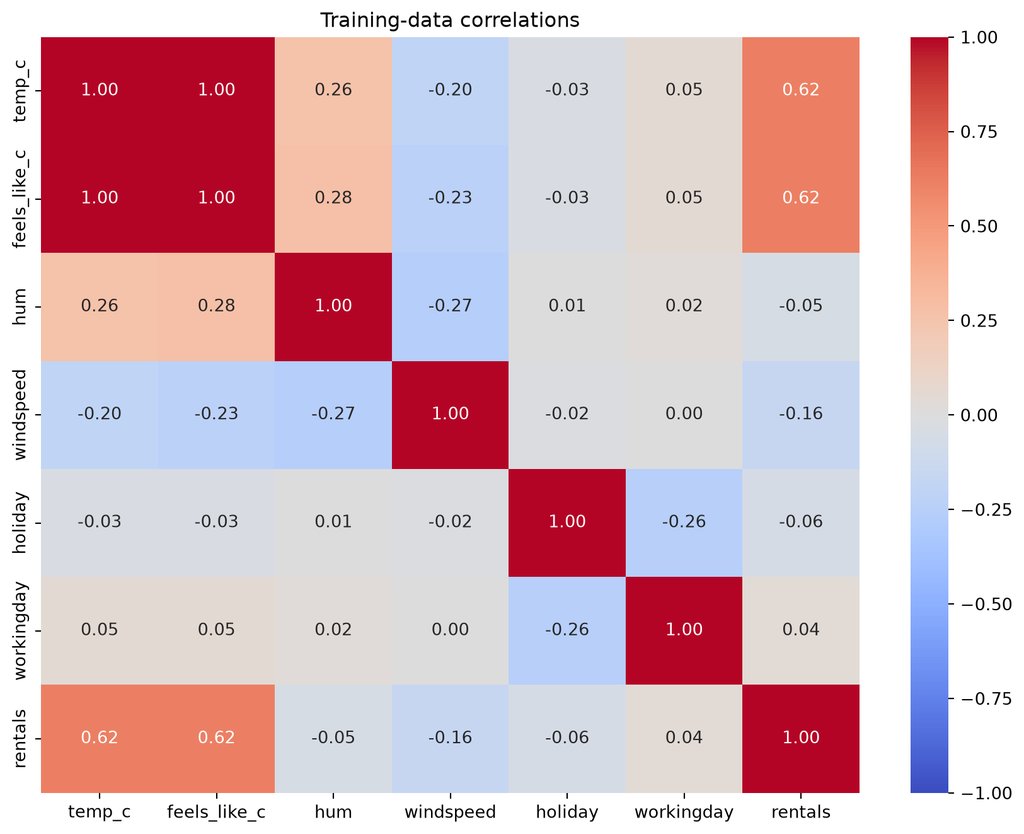

```python
correlation_data = X_train.select(
    "temp_c", "feels_like_c", "hum", "windspeed", "holiday", "workingday"
).with_columns(pl.Series("rentals", y_train))
correlation = correlation_data.to_pandas().corr()

plt.figure(figsize=(9, 7))
sns.heatmap(correlation, annot=True, fmt=".2f", cmap="coolwarm", vmin=-1, vmax=1)
plt.title("Training-data correlations")
plt.tight_layout()
plt.show()
```

## Select the temperature feature

**Johnny, Data Science Intern:** Looking at the features we have, how do you think we should handle the temperature features?

```python
# Use the same input columns for training, validation, testing, and recovery plots.
X = X.drop("temp_c")
X_train = X_train.drop("temp_c")
X_validation = X_validation.drop("temp_c")
X_test = X_test.drop("temp_c")
```

## Scale the data

Fit the scaler on training data and reuse it for validation and testing.

```python
norm = MinMaxScaler().fit(X_train)
X_train = norm.transform(X_train)
X_validation = norm.transform(X_validation)
X_test = norm.transform(X_test)
```

## Compare model settings

**Johnny, Data Science Intern:** What are you planning to use for the loss function?

Start with mean squared error (MSE), which gives larger rental-count errors more weight. The experiment also tests mean absolute error (MAE). All trials use validation MSE for early stopping and validation RMSE for model selection, so the losses are compared using the same evaluation measure. The final model uses the loss from the selected trial.

```python
# Start with the current model, then test small changes.
defaults = {
    "learning_rate": 0.0003, "hidden_layers": [128, 256, 64],
    "batch_size": 32, "activation": "relu", "optimizer": "Adam",
    "loss": "mean_squared_error",
}
experiments = [
    ("Current settings", "Baseline", {}),
    ("Learning rate 0.001", "Learning rate (B)", {"learning_rate": 0.001}),
    ("Learning rate 0.003", "Learning rate (B)", {"learning_rate": 0.003}),
    ("Two hidden layers: 128, 64", "Network size (A)", {"hidden_layers": [128, 64]}),
    ("Batch size 64", "Batch size (C)", {"batch_size": 64}),
    ("ELU activation", "Activation (D)", {"activation": "elu"}),
    ("RMSprop optimizer", "Optimizer (B)", {"optimizer": "RMSprop"}),
    ("Mean absolute error loss", "Loss function (D)", {"loss": "mean_absolute_error"}),
]

trial_results = []
best_validation_rmse = float("inf")
for name, aspect, changes in experiments:
    keras.backend.clear_session()
    keras.utils.set_random_seed(42)
    settings = {**defaults, **changes}
    print(f"Training: {name}", flush=True)

    trial_model = Sequential([Input(shape=(X_train.shape[1],))])
    for layer_number, neurons in enumerate(settings["hidden_layers"]):
        trial_model.add(Dense(neurons, activation=settings["activation"]))
        if layer_number == 0:
            trial_model.add(Dropout(0.2))
    trial_model.add(Dense(1))

    optimizer_class = {"Adam": keras.optimizers.Adam, "RMSprop": keras.optimizers.RMSprop}
    trial_model.compile(
        optimizer=optimizer_class[settings["optimizer"]](learning_rate=settings["learning_rate"]),
        loss=settings["loss"], metrics=["mse"],
    )
    early_stop = keras.callbacks.EarlyStopping(
        monitor="val_mse", patience=30, restore_best_weights=True
    )
    trial_history = trial_model.fit(
        X_train, y_train,
        validation_data=(X_validation, y_validation),
        epochs=500, batch_size=settings["batch_size"],
        callbacks=[early_stop], verbose=0,
    )
    validation_predictions = np.clip(
        trial_model.predict(X_validation, verbose=0).ravel(), 0, None
    )
    validation_rmse = float(root_mean_squared_error(y_validation, validation_predictions))
    trial_results.append({
        "experiment": name, "aspect": aspect,
        "learning_rate": settings["learning_rate"],
        "validation_rmse": validation_rmse,
        "validation_r2": float(r2_score(y_validation, validation_predictions)),
        "best_epoch": int(np.argmin(trial_history.history["val_mse"])) + 1,
        "epochs_trained": len(trial_history.history["loss"]),
    })
    print(f"Validation RMSE: {validation_rmse:,.2f}", flush=True)
    if validation_rmse < best_validation_rmse:
        best_validation_rmse = validation_rmse
        model, history = trial_model, trial_history
        best_experiment = name

comparison = pl.DataFrame(trial_results).sort("validation_rmse")
print(f"Selected using validation data: {best_experiment}")
comparison.select(
    "experiment", "validation_rmse", "validation_r2", "best_epoch", "epochs_trained"
).with_columns(pl.col("validation_rmse").round(2), pl.col("validation_r2").round(4))
```

```
WARNING:tensorflow:From C:\Users\haymo\AppData\Local\Programs\Python\Python312\Lib\site-packages\keras\src\backend\common\global_state.py:82: The name tf.reset_default_graph is deprecated. Please use tf.compat.v1.reset_default_graph instead.

Training: Current settings
WARNING:tensorflow:TensorFlow GPU support is not available on native Windows for TensorFlow >= 2.11. Even if CUDA/cuDNN are installed, GPU will not be used. Please use WSL2 or the TensorFlow-DirectML plugin.
Validation RMSE: 1,140.28
Training: Learning rate 0.001
Validation RMSE: 1,150.53
Training: Learning rate 0.003
Validation RMSE: 1,146.55
Training: Two hidden layers: 128, 64
Validation RMSE: 1,337.36
Training: Batch size 64
Validation RMSE: 1,161.35
Training: ELU activation
Validation RMSE: 1,101.68
Training: RMSprop optimizer
Validation RMSE: 1,139.40
Training: Mean absolute error loss
Validation RMSE: 1,151.77
Selected using validation data: ELU activation
```

shape: (8, 5)

| experiment str | validation_rmse f64 | validation_r2 f64 | best_epoch i64 | epochs_trained i64 |
| --- | --- | --- | --- | --- |
| "ELU activation" | 1101.68 | 0.9182 | 461 | 491 |
| "RMSprop optimizer" | 1139.4 | 0.9125 | 497 | 500 |
| "Current settings" | 1140.28 | 0.9124 | 497 | 500 |
| "Learning rate 0.003" | 1146.55 | 0.9114 | 89 | 119 |
| "Learning rate 0.001" | 1150.53 | 0.9108 | 213 | 243 |
| "Mean absolute error loss" | 1151.77 | 0.9106 | 435 | 465 |
| "Batch size 64" | 1161.35 | 0.9091 | 499 | 500 |
| "Two hidden layers: 128, 64" | 1337.36 | 0.8795 | 498 | 500 |

The table compares these settings under a 500-epoch limit and one fixed random seed. A trial that reaches that limit may need more training. These experiments identify the best setting tested here; they do not establish a globally optimal configuration.

## Plot training and validation error

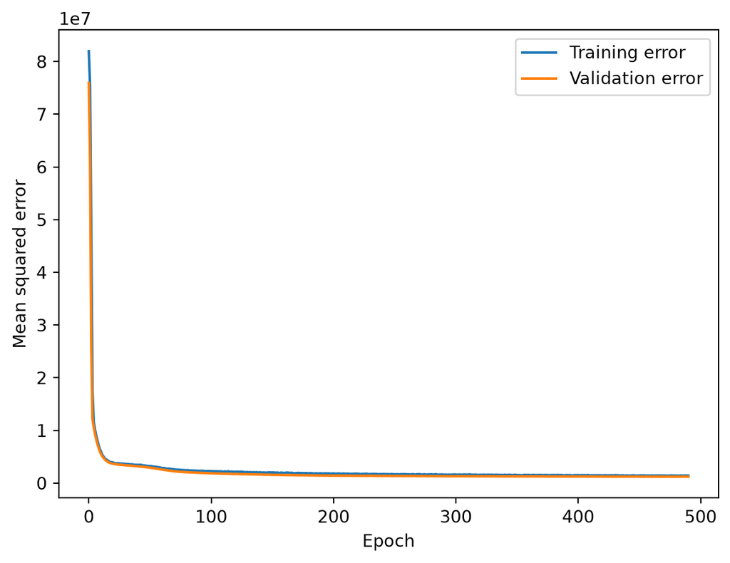

```python
plt.plot(history.history["mse"], label="Training error")
plt.plot(history.history["val_mse"], label="Validation error")
plt.xlabel("Epoch")
plt.ylabel("Mean squared error")
plt.legend()
plt.show()
```

## Predict and evaluate

**Johnny, Data Science Intern:** How will we know if our model has strong predictive power?

```python
predictions = np.clip(model.predict(X_test, verbose=0).ravel(), 0, None)

print(f"RMSE: {root_mean_squared_error(y_test, predictions):,.2f} rentals per day")
print(f"R2: {r2_score(y_test, predictions):.4f}")

results = pl.DataFrame({"actual": y_test, "predictions": predictions}).with_columns(
    (pl.col("actual") - pl.col("predictions")).alias("difference")
)
results.head(10)
```

```
RMSE: 1,194.87 rentals per day
R2: 0.9021
```

shape: (10, 3)

| actual f32 | predictions f32 | difference f32 |
| --- | --- | --- |
| 7731.0 | 7841.476562 | -110.476562 |
| 8590.0 | 10162.591797 | -1572.591797 |
| 6864.0 | 6141.130371 | 722.869629 |
| 4102.0 | 4252.972168 | -150.972168 |
| 5324.0 | 5561.796387 | -237.796387 |
| 15250.0 | 13971.946289 | 1278.053711 |
| 13485.0 | 14233.849609 | -748.849609 |
| 6785.0 | 7139.668457 | -354.668457 |
| 8178.0 | 9122.926758 | -944.926758 |
| 8210.0 | 7728.515137 | 481.484863 |

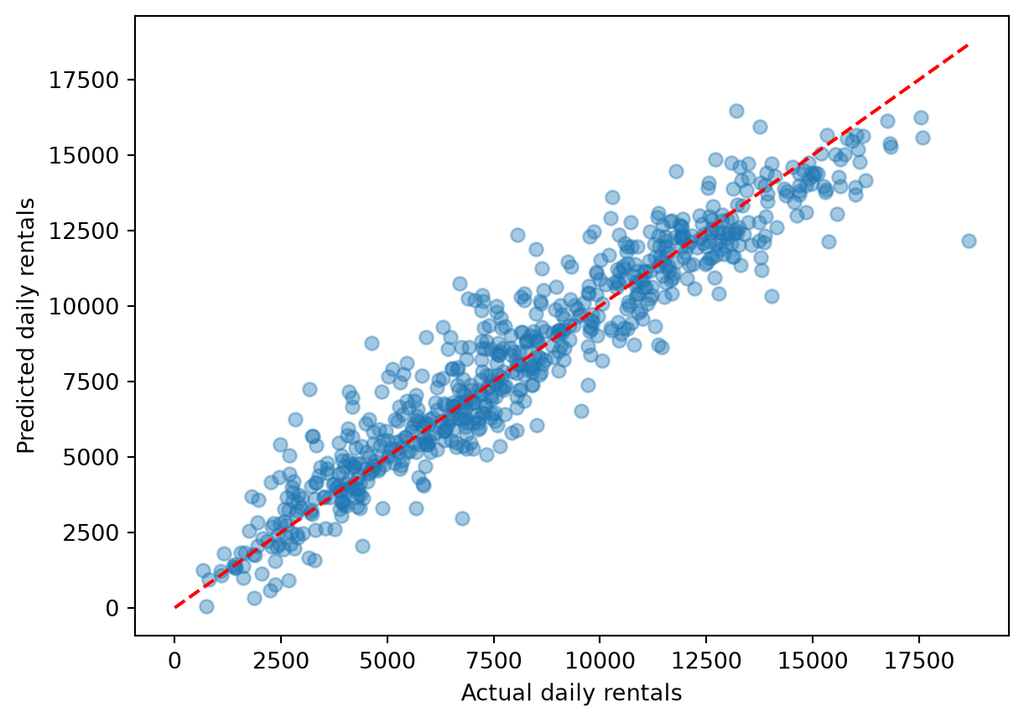

```python
plt.scatter(y_test, predictions, alpha=0.4)
plt.plot([0, y_test.max()], [0, y_test.max()], "r--")
plt.xlabel("Actual daily rentals")
plt.ylabel("Predicted daily rentals")
plt.show()
```

## Questions from stakeholders

Zhao, CEO of WelcomeBike: If you run your model on the data and the results seem lower than you expected, which of the following hyperparameters do you feel has the most potential for model improvement? A. Number of neurons and number of hidden layers. B. Learning rate and optimizer selection. C. Batch size and number of epochs. D. Activation functions of the layers and overall loss function.

What approach do you think you’re going to take to find the optimal learning rate?

**Model-improvement experiment:** The comparison above tests options A through D using validation data. Learning rate and optimizer selection (B) are useful first candidates to investigate; the table shows whether they helped relative to the current settings. The selected trial supplies the learning curve and final test results above.

**Learning-rate approach:** Compare Adam learning rates of 0.0003, 0.001, and 0.003 while holding the network, batch size, activation, and loss fixed. Select the best tested rate using validation RMSE. MSE and RMSE measure errors in squared rentals and rentals per day respectively; R2 provides a second view of predictive performance.

```python
learning_rates = comparison.filter(
    pl.col("aspect").is_in(["Baseline", "Learning rate (B)"])
).sort("learning_rate")
baseline_rmse = comparison.filter(pl.col("aspect") == "Baseline")["validation_rmse"][0]
best_rate = learning_rates.sort("validation_rmse").row(0, named=True)
best_trial = comparison.row(0, named=True)
print(f"Best tested Adam learning rate: {best_rate['learning_rate']}")
print(f"Best overall trial: {best_trial['experiment']}")
print(f"Validation RMSE: {best_trial['validation_rmse']:,.2f} rentals per day")
print(f"Reduction from current settings: {100 * (baseline_rmse - best_trial['validation_rmse']) / baseline_rmse:.2f}%")
learning_rates.select(
    "learning_rate", "validation_rmse", "validation_r2", "epochs_trained"
).with_columns(pl.col("validation_rmse").round(2), pl.col("validation_r2").round(4))
```

```
Best tested Adam learning rate: 0.0003
Best overall trial: ELU activation
Validation RMSE: 1,101.68 rentals per day
Reduction from current settings: 3.38%
```

shape: (3, 4)

| learning_rate f64 | validation_rmse f64 | validation_r2 f64 | epochs_trained i64 |
| --- | --- | --- | --- |
| 0.0003 | 1140.28 | 0.9124 | 500 |
| 0.001 | 1150.53 | 0.9108 | 243 |
| 0.003 | 1146.55 | 0.9114 | 119 |

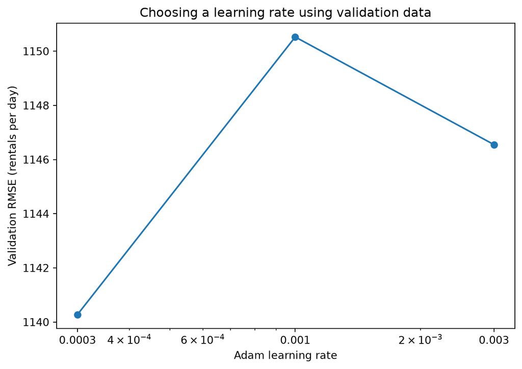

```python
plt.semilogx(learning_rates["learning_rate"], learning_rates["validation_rmse"], "o-")
plt.xticks(learning_rates["learning_rate"].to_list(), ["0.0003", "0.001", "0.003"])
plt.xlabel("Adam learning rate")
plt.ylabel("Validation RMSE (rentals per day)")
plt.title("Choosing a learning rate using validation data")
plt.tight_layout()
plt.show()
```

Coming out of the pandemic has put a strain on resources. Our customers are much more concerned about health and safety of sharing bikes. In your executive summary, would you add your recommendations for when we could pull bikes out of rotation to clean and disinfect them? For example, what days and times we should bring them in? We also need to know if we have any lasting problems now that we are a few years past COVID-19. What can we expect for forcasts into the future? Are we back on track or still recovering?

### Cleaning schedule: days and hours

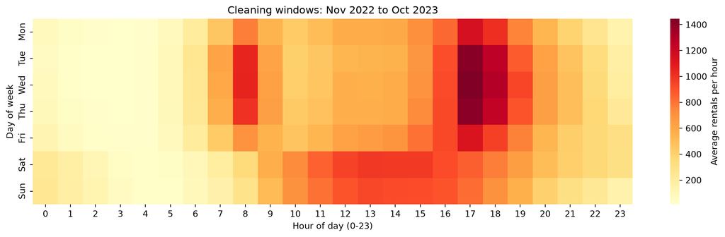

```python
from datetime import timedelta

# Exclude the final month if its last date has not been observed.
last_date = bikes["dteday"].max()
end_date = daily.select(
    pl.col("dteday").max().dt.truncate("1mo").dt.offset_by("1mo")
).item()
if last_date != end_date - timedelta(days=1):
    end_date = last_date.replace(day=1)
start_date = pl.Series([end_date]).dt.offset_by("-1y")[0]

hourly_demand = (
    bikes.filter((pl.col("dteday") >= start_date) & (pl.col("dteday") < end_date))
    .with_columns(
        pl.col("dteday").dt.weekday().alias("weekday"),
        pl.col("hr").cast(pl.Int64).alias("hour"),
        (pl.col("casual") + pl.col("registered")).alias("rentals"),
    )
    .group_by("weekday", "hour").agg(pl.col("rentals").mean())
)
heatmap = hourly_demand.pivot(on="hour", index="weekday", values="rentals").sort("weekday")

plt.figure(figsize=(13, 4))
sns.heatmap(
    heatmap.select([str(hour) for hour in range(24)]).to_numpy(),
    cmap="YlOrRd", xticklabels=range(24),
    yticklabels=["Mon", "Tue", "Wed", "Thu", "Fri", "Sat", "Sun"],
    cbar_kws={"label": "Average rentals per hour"},
)
plt.xlabel("Hour of day (0-23)")
plt.ylabel("Day of week")
plt.title(f"Cleaning windows: {start_date:%b %Y} to {end_date - timedelta(days=1):%b %Y}")
plt.tight_layout()
plt.show()
```

### Rental-demand recovery compared with 2019

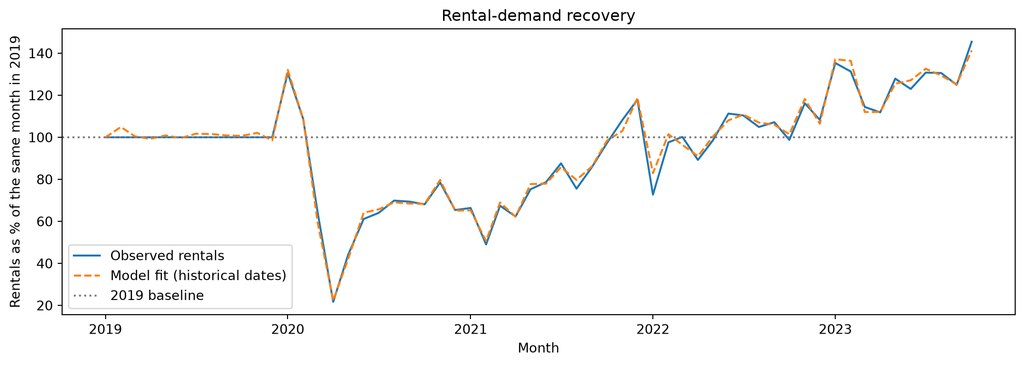

```python
# Reuse the trained winner and the same fitted scaler from the model section.
fitted_rentals = np.clip(model.predict(norm.transform(X), verbose=0).ravel(), 0, None)
monthly = (
    daily.with_columns(pl.Series("model_rentals", fitted_rentals))
    .filter(pl.col("dteday") < end_date)
    .with_columns(pl.col("dteday").dt.truncate("1mo").alias("month_start"))
    .group_by("month_start")
    .agg(pl.col("rentals", "model_rentals").mean())
    .with_columns(
        pl.col("month_start").dt.year().alias("year"),
        pl.col("month_start").dt.month().alias("month"),
    )
)
baseline_2019 = monthly.filter(pl.col("year") == 2019).select(
    "month", pl.col("rentals").alias("baseline_rentals")
)
recovery = (
    monthly.filter(pl.col("year") >= 2019)
    .join(baseline_2019, on="month")
    .with_columns(
        (100 * pl.col("rentals") / pl.col("baseline_rentals")).alias("actual_percent"),
        (100 * pl.col("model_rentals") / pl.col("baseline_rentals")).alias("model_percent"),
    ).sort("month_start")
)

plt.figure(figsize=(11, 4))
plt.plot(recovery["month_start"], recovery["actual_percent"], label="Observed rentals")
plt.plot(recovery["month_start"], recovery["model_percent"], "--", label="Model fit (historical dates)")
plt.axhline(100, color="gray", linestyle=":", label="2019 baseline")
plt.xlabel("Month")
plt.ylabel("Rentals as % of the same month in 2019")
plt.title("Rental-demand recovery")
plt.legend()
plt.tight_layout()
plt.show()
```

## Predict rentals for each hour in the new dataset

```python
from sklearn.compose import ColumnTransformer
from sklearn.preprocessing import OneHotEncoder

december = pl.read_csv(
    "https://raw.githubusercontent.com/byui-cse/cse450-course/master/data/bikes_december.csv"
).with_columns(pl.col("dteday").str.strptime(pl.Date, "%m/%d/%Y"))

# Only use labeled observations before the requested prediction dates.
hourly_history = bikes.filter(pl.col("dteday") < december["dteday"].min())

def hourly_features(data):
    return data.select(
        "feels_like_c", "hum", "windspeed", "holiday", "workingday",
        pl.col("hr").cast(pl.Int64),
        "season", "weathersit",
        pl.col("dteday").dt.year().alias("year"),
        pl.col("dteday").dt.month().alias("month"),
        pl.col("dteday").dt.weekday().alias("weekday"),
    ).to_pandas()

hourly_inputs = hourly_features(hourly_history)
forecast_inputs = hourly_features(december)
# Scaling the target to thousands of rentals makes network training easier.
hourly_targets = (
    hourly_history["casual"] + hourly_history["registered"]
).to_numpy().astype(np.float32) / 1000

hourly_cutoff = hourly_history.select(
    pl.col("dteday").max().dt.offset_by("-2mo")
).item()
hourly_train_mask = (hourly_history["dteday"] < hourly_cutoff).to_numpy()

hourly_preprocessor = ColumnTransformer([
    ("numeric", MinMaxScaler(),
     ["feels_like_c", "hum", "windspeed", "holiday", "workingday", "year"]),
    ("categorical", OneHotEncoder(handle_unknown="ignore", sparse_output=False),
     ["hr", "season", "weathersit", "month", "weekday"]),
])
hourly_train = hourly_preprocessor.fit_transform(
    hourly_inputs.loc[hourly_train_mask]
).astype(np.float32)
hourly_validation = hourly_preprocessor.transform(
    hourly_inputs.loc[~hourly_train_mask]
).astype(np.float32)
december
```

shape: (1_465, 10)

| dteday date | hr f64 | temp_c f64 | feels_like_c f64 | hum f64 | windspeed f64 | weathersit i64 | season i64 | holiday i64 | workingday i64 |
| --- | --- | --- | --- | --- | --- | --- | --- | --- | --- |
| 2023-11-01 | 0.0 | 6.0 | 3.8 | 0.6359 | 10.8 | 1 | 4 | 0 | 1 |
| 2023-11-01 | 1.0 | 6.0 | 3.4 | 0.6333 | 12.7 | 1 | 4 | 0 | 1 |
| 2023-11-01 | 2.0 | 5.3 | 2.6 | 0.6598 | 12.0 | 1 | 4 | 0 | 1 |
| 2023-11-01 | 3.0 | 5.1 | 3.8 | 0.6636 | 6.3 | 1 | 4 | 0 | 1 |
| 2023-11-01 | 4.0 | 4.0 | 1.8 | 0.7192 | 8.4 | 1 | 4 | 0 | 1 |
| … | … | … | … | … | … | … | … | … | … |
| 2023-12-31 | 19.0 | 6.9 | 4.8 | 0.5846 | 10.5 | 1 | 1 | 0 | 0 |
| 2023-12-31 | 20.0 | 6.4 | 4.3 | 0.6305 | 10.1 | 1 | 1 | 0 | 0 |
| 2023-12-31 | 21.0 | 6.4 | 4.0 | 0.6323 | 11.9 | 2 | 1 | 0 | 0 |
| 2023-12-31 | 22.0 | 6.4 | 5.0 | 0.6597 | 7.1 | 2 | 1 | 0 | 0 |
| 2023-12-31 | 23.0 | 5.8 | 4.0 | 0.6606 | 8.4 | 1 | 1 | 0 | 0 |

```python
def build_hourly_model(number_of_inputs):
    keras.utils.set_random_seed(42)
    network = Sequential([
        Input(shape=(number_of_inputs,)),
        Dense(128, activation="relu"),
        Dropout(0.2),
        Dense(256, activation="relu"),
        Dense(64, activation="relu"),
        Dense(1),
    ])
    network.compile(
        optimizer=keras.optimizers.Adam(learning_rate=defaults["learning_rate"]),
        loss="mean_squared_error",
    )
    return network

hourly_model = build_hourly_model(hourly_train.shape[1])
print("Training the hourly model with chronological validation...", flush=True)
hourly_history_fit = hourly_model.fit(
    hourly_train, hourly_targets[hourly_train_mask],
    validation_data=(hourly_validation, hourly_targets[~hourly_train_mask]),
    epochs=150, batch_size=256, verbose=0,
    callbacks=[keras.callbacks.EarlyStopping(
        monitor="val_loss", patience=10, restore_best_weights=True
    )],
)
hourly_epochs = int(np.argmin(hourly_history_fit.history["val_loss"])) + 1
hourly_validation_predictions = np.clip(
    hourly_model.predict(hourly_validation, verbose=0).ravel() * 1000, 0, None
)
hourly_validation_actual = hourly_targets[~hourly_train_mask] * 1000
print(f"Hourly validation dates: {hourly_cutoff} to {hourly_history['dteday'].max()}")
print(f"Selected epochs: {hourly_epochs}")
print(f"Hourly validation RMSE: {root_mean_squared_error(hourly_validation_actual, hourly_validation_predictions):,.2f}")
print(f"Hourly validation R2: {r2_score(hourly_validation_actual, hourly_validation_predictions):.4f}")
```

```
Training the hourly model with chronological validation...
Hourly validation dates: 2023-08-31 to 2023-10-31
Selected epochs: 2
Hourly validation RMSE: 242.86
Hourly validation R2: 0.7653
```

### Export december predictions

```python
hourly_all = hourly_preprocessor.fit_transform(hourly_inputs).astype(np.float32)
hourly_forecast = hourly_preprocessor.transform(forecast_inputs).astype(np.float32)
hourly_model = build_hourly_model(hourly_all.shape[1])
print("Training on all historical rows before exporting...", flush=True)
hourly_model.fit(
    hourly_all, hourly_targets,
    epochs=hourly_epochs, batch_size=256, verbose=0,
)

december_predictions = np.clip(
    hourly_model.predict(hourly_forecast, verbose=0).ravel() * 1000, 0, None
)
assert len(december_predictions) == december.height
assert np.isfinite(december_predictions).all()
december_predictions = np.rint(december_predictions).astype(np.int64)

prediction_export = pl.DataFrame({"predictions": december_predictions})
prediction_export.write_csv("bikes_december_predictions.csv")
print(f"Exported {prediction_export.height:,} hourly predictions to bikes_december_predictions.csv")

december_daily_totals = (
    december.with_columns(pl.Series("predicted_total_rentals", december_predictions))
    .group_by("dteday").agg(pl.col("predicted_total_rentals").sum())
    .sort("dteday")
)
december_daily_totals
```

```
Training on all historical rows before exporting...
Exported 1,465 hourly predictions to bikes_december_predictions.csv
```

shape: (61, 2)

| dteday date | predicted_total_rentals i64 |
| --- | --- |
| 2023-11-01 | 7881 |
| 2023-11-02 | 9163 |
| 2023-11-03 | 8648 |
| 2023-11-04 | 10507 |
| 2023-11-05 | 9458 |
| … | … |
| 2023-12-27 | 2236 |
| 2023-12-28 | 4176 |
| 2023-12-29 | 4290 |
| 2023-12-30 | 4213 |
| 2023-12-31 | 3861 |